```python
# import all packages and set plots to be embedded inline
import numpy as np
import pandas as pd
import matplotlib.pyplot as plt
import seaborn as sb

%matplotlib inline

# suppress warnings from final output
import warnings
warnings.simplefilter("ignore")
```

```python
#load data
df = pd.read_csv(r"C:\Users\mayan\Downloads\vgsales.csv")
```

```python
#checking the dataset
df.info
```

```
<bound method DataFrame.info of         Rank                                              Name Platform  \
0          1                                        Wii Sports      Wii
1          2                                 Super Mario Bros.      NES
2          3                                    Mario Kart Wii      Wii
3          4                                 Wii Sports Resort      Wii
4          5                          Pokemon Red/Pokemon Blue       GB
...      ...                                               ...      ...
16593  16596                Woody Woodpecker in Crazy Castle 5      GBA
16594  16597                     Men in Black II: Alien Escape       GC
16595  16598  SCORE International Baja 1000: The Official Game      PS2
16596  16599                                        Know How 2       DS
16597  16600                                  Spirits & Spells      GBA

         Year         Genre   Publisher  NA_Sales  EU_Sales  JP_Sales  \
0      2006.0        Sports    Nintendo     41.49     29.02      3.77
```

[output cut: 25 more lines]

# Assess

```python
#TOP 25 HEADING
df.head(25)
```

|  | Rank | Name | Platform | Year | Genre | Publisher | NA_Sales | EU_Sales | JP_Sales | Other_Sales | Global_Sales |
| --- | --- | --- | --- | --- | --- | --- | --- | --- | --- | --- | --- |
| 0 | 1 | Wii Sports | Wii | 2006.0 | Sports | Nintendo | 41.49 | 29.02 | 3.77 | 8.46 | 82.74 |
| 1 | 2 | Super Mario Bros. | NES | 1985.0 | Platform | Nintendo | 29.08 | 3.58 | 6.81 | 0.77 | 40.24 |
| 2 | 3 | Mario Kart Wii | Wii | 2008.0 | Racing | Nintendo | 15.85 | 12.88 | 3.79 | 3.31 | 35.82 |
| 3 | 4 | Wii Sports Resort | Wii | 2009.0 | Sports | Nintendo | 15.75 | 11.01 | 3.28 | 2.96 | 33.00 |
| 4 | 5 | Pokemon Red/Pokemon Blue | GB | 1996.0 | Role-Playing | Nintendo | 11.27 | 8.89 | 10.22 | 1.00 | 31.37 |
| 5 | 6 | Tetris | GB | 1989.0 | Puzzle | Nintendo | 23.20 | 2.26 | 4.22 | 0.58 | 30.26 |
| 6 | 7 | New Super Mario Bros. | DS | 2006.0 | Platform | Nintendo | 11.38 | 9.23 | 6.50 | 2.90 | 30.01 |
| 7 | 8 | Wii Play | Wii | 2006.0 | Misc | Nintendo | 14.03 | 9.20 | 2.93 | 2.85 | 29.02 |
| 8 | 9 | New Super Mario Bros. Wii | Wii | 2009.0 | Platform | Nintendo | 14.59 | 7.06 | 4.70 | 2.26 | 28.62 |
| 9 | 10 | Duck Hunt | NES | 1984.0 | Shooter | Nintendo | 26.93 | 0.63 | 0.28 | 0.47 | 28.31 |
| 10 | 11 | Nintendogs | DS | 2005.0 | Simulation | Nintendo | 9.07 | 11.00 | 1.93 | 2.75 | 24.76 |
| 11 | 12 | Mario Kart DS | DS | 2005.0 | Racing | Nintendo | 9.81 | 7.57 | 4.13 | 1.92 | 23.42 |
| 12 | 13 | Pokemon Gold/Pokemon Silver | GB | 1999.0 | Role-Playing | Nintendo | 9.00 | 6.18 | 7.20 | 0.71 | 23.10 |
| 13 | 14 | Wii Fit | Wii | 2007.0 | Sports | Nintendo | 8.94 | 8.03 | 3.60 | 2.15 | 22.72 |
| 14 | 15 | Wii Fit Plus | Wii | 2009.0 | Sports | Nintendo | 9.09 | 8.59 | 2.53 | 1.79 | 22.00 |
| 15 | 16 | Kinect Adventures! | X360 | 2010.0 | Misc | Microsoft Game Studios | 14.97 | 4.94 | 0.24 | 1.67 | 21.82 |
| 16 | 17 | Grand Theft Auto V | PS3 | 2013.0 | Action | Take-Two Interactive | 7.01 | 9.27 | 0.97 | 4.14 | 21.40 |
| 17 | 18 | Grand Theft Auto: San Andreas | PS2 | 2004.0 | Action | Take-Two Interactive | 9.43 | 0.40 | 0.41 | 10.57 | 20.81 |
| 18 | 19 | Super Mario World | SNES | 1990.0 | Platform | Nintendo | 12.78 | 3.75 | 3.54 | 0.55 | 20.61 |
| 19 | 20 | Brain Age: Train Your Brain in Minutes a Day | DS | 2005.0 | Misc | Nintendo | 4.75 | 9.26 | 4.16 | 2.05 | 20.22 |
| 20 | 21 | Pokemon Diamond/Pokemon Pearl | DS | 2006.0 | Role-Playing | Nintendo | 6.42 | 4.52 | 6.04 | 1.37 | 18.36 |
| 21 | 22 | Super Mario Land | GB | 1989.0 | Platform | Nintendo | 10.83 | 2.71 | 4.18 | 0.42 | 18.14 |
| 22 | 23 | Super Mario Bros. 3 | NES | 1988.0 | Platform | Nintendo | 9.54 | 3.44 | 3.84 | 0.46 | 17.28 |
| 23 | 24 | Grand Theft Auto V | X360 | 2013.0 | Action | Take-Two Interactive | 9.63 | 5.31 | 0.06 | 1.38 | 16.38 |
| 24 | 25 | Grand Theft Auto: Vice City | PS2 | 2002.0 | Action | Take-Two Interactive | 8.41 | 5.49 | 0.47 | 1.78 | 16.15 |

```python
#CHECKING THE NUMBER OF ROWS AND COLUMNS
df.shape
```

```
(16598, 11)
```

```python
#SUMMARY STATISTICS
df.describe()
```

|  | Rank | Year | NA_Sales | EU_Sales | JP_Sales | Other_Sales | Global_Sales |
| --- | --- | --- | --- | --- | --- | --- | --- |
| count | 16598.000000 | 16327.000000 | 16598.000000 | 16598.000000 | 16598.000000 | 16598.000000 | 16598.000000 |
| mean | 8300.605254 | 2006.406443 | 0.264667 | 0.146652 | 0.077782 | 0.048063 | 0.537441 |
| std | 4791.853933 | 5.828981 | 0.816683 | 0.505351 | 0.309291 | 0.188588 | 1.555028 |
| min | 1.000000 | 1980.000000 | 0.000000 | 0.000000 | 0.000000 | 0.000000 | 0.010000 |
| 25% | 4151.250000 | 2003.000000 | 0.000000 | 0.000000 | 0.000000 | 0.000000 | 0.060000 |
| 50% | 8300.500000 | 2007.000000 | 0.080000 | 0.020000 | 0.000000 | 0.010000 | 0.170000 |
| 75% | 12449.750000 | 2010.000000 | 0.240000 | 0.110000 | 0.040000 | 0.040000 | 0.470000 |
| max | 16600.000000 | 2020.000000 | 41.490000 | 29.020000 | 10.220000 | 10.570000 | 82.740000 |

```python
df.info()
```

```
<class 'pandas.core.frame.DataFrame'>
RangeIndex: 16598 entries, 0 to 16597
Data columns (total 11 columns):
 #   Column        Non-Null Count  Dtype
---  ------        --------------  -----
 0   Rank          16598 non-null  int64
 1   Name          16598 non-null  object
 2   Platform      16598 non-null  object
 3   Year          16327 non-null  float64
 4   Genre         16598 non-null  object
 5   Publisher     16540 non-null  object
 6   NA_Sales      16598 non-null  float64
 7   EU_Sales      16598 non-null  float64
 8   JP_Sales      16598 non-null  float64
 9   Other_Sales   16598 non-null  float64
 10  Global_Sales  16598 non-null  float64
dtypes: float64(6), int64(1), object(4)
memory usage: 1.4+ MB
```

```python
#unique values from the 'Year' column
sorted(list(df.Year.unique()))
```

```
[1980.0,
 1981.0,
 1982.0,
 1983.0,
 1984.0,
 1985.0,
 1986.0,
 1987.0,
 1988.0,
 1989.0,
 1990.0,
 1991.0,
 1992.0,
 1993.0,
 1994.0,
 1995.0,
 1996.0,
 1997.0,
 1998.0,
 1999.0,
 2000.0,
 2001.0,
 2002.0,
 2003.0,
 2004.0,
 2005.0,
 2006.0,
 2007.0,
 2008.0,
 2009.0,
 2010.0,
 2011.0,
 2012.0,
 2013.0,
 2014.0,
 2015.0,
 nan,
 2016.0,
 2017.0,
 2020.0]
```

```python
#unique value in the 'Genre' column
df.Genre.value_counts()
```

```
Genre
Action          3316
Sports          2346
Misc            1739
Role-Playing    1488
Shooter         1310
Adventure       1286
Racing          1249
Platform         886
Simulation       867
Fighting         848
Strategy         681
Puzzle           582
Name: count, dtype: int64
```

```python
#the minimum value in the 'Global_Sales' column
df['Global_Sales'].min()
```

```
0.01
```

```python
#comparision of minimum global sales with other rows
test = df[df['Global_Sales']>0.01]
test[test['Global_Sales'] != test['NA_Sales']+test['EU_Sales']+test['JP_Sales']+test['Other_Sales']].shape[0]
```

```
6761
```

```python
#CHECKING DUPLICATES
df[df.duplicated()].shape[0]
```

```
0
```

# CHECKING FOR MISSING VALUES

```python
df.isna().sum()
```

```
Rank              0
Name              0
Platform          0
Year            271
Genre             0
Publisher        58
NA_Sales          0
EU_Sales          0
JP_Sales          0
Other_Sales       0
Global_Sales      0
dtype: int64
```

```python
df.isna().sum().sum()
```

```
329
```

There are aroud 271 records in Year column and around 58 records in Publisher column whoch are NA Value records= 329 record

```python
df_copy = df.copy()
```

```python
df_copy.dropna(axis=0, how='any',inplace=True)
```

```python
df_copy.info()
```

```
<class 'pandas.core.frame.DataFrame'>
Index: 16291 entries, 0 to 16597
Data columns (total 11 columns):
 #   Column        Non-Null Count  Dtype
---  ------        --------------  -----
 0   Rank          16291 non-null  int64
 1   Name          16291 non-null  object
 2   Platform      16291 non-null  object
 3   Year          16291 non-null  float64
 4   Genre         16291 non-null  object
 5   Publisher     16291 non-null  object
 6   NA_Sales      16291 non-null  float64
 7   EU_Sales      16291 non-null  float64
 8   JP_Sales      16291 non-null  float64
 9   Other_Sales   16291 non-null  float64
 10  Global_Sales  16291 non-null  float64
dtypes: float64(6), int64(1), object(4)
memory usage: 1.5+ MB
```

```python
#deleting data without year and publisher
```

```python
df_copy.dropna(axis=0, how='any',inplace=True)
```

```python
df_copy.info()
```

```
<class 'pandas.core.frame.DataFrame'>
Index: 16291 entries, 0 to 16597
Data columns (total 11 columns):
 #   Column        Non-Null Count  Dtype
---  ------        --------------  -----
 0   Rank          16291 non-null  int64
 1   Name          16291 non-null  object
 2   Platform      16291 non-null  object
 3   Year          16291 non-null  float64
 4   Genre         16291 non-null  object
 5   Publisher     16291 non-null  object
 6   NA_Sales      16291 non-null  float64
 7   EU_Sales      16291 non-null  float64
 8   JP_Sales      16291 non-null  float64
 9   Other_Sales   16291 non-null  float64
 10  Global_Sales  16291 non-null  float64
dtypes: float64(6), int64(1), object(4)
memory usage: 1.5+ MB
```

6761 rows have wrong Global_Sales numbers,: Aingdd up 'NA_Sales', 'EU_Sales', 'JP_Sales', 'Other_Sales' and save them into 'Global_Sales' column

```python
df_copy['Global_Sales'] = df_copy['NA_Sales'] + df_copy['EU_Sales'] + df_copy['JP_Sales']+df_copy['Other_Sales']
```

```python
df_copy[df_copy['Global_Sales'] != df_copy['NA_Sales']+df_copy['EU_Sales']+df_copy['JP_Sales']+df_copy['Other_Sales']].shape[0]
```

```
0
```

there is 0 row which has wrong global sales number now.

## FINAL STEP

```python
# store the file
df_copy.reset_index(drop=True)
df_copy.to_csv('clean_vgsales.csv')
```

```python
#load data
clean_df = pd.read_csv('clean_vgsales.csv')
```

## EDA

```python
clean_df['Publisher'].value_counts().describe()
```

```
count     576.000000
mean       28.282986
std       115.417374
min         1.000000
25%         1.000000
50%         3.000000
75%        10.000000
max      1339.000000
Name: count, dtype: float64
```

there are almost 50% publishers which had only published less than or equal 3 games,choosing the publishers who had published more than 3 games.

```python
# find the list of the publishers who had published more than 3 games
publishers_more_than_3_list = list(clean_df['Publisher'].value_counts()[clean_df['Publisher'].value_counts()>3].index)
```

```python
#data who are from these publishers
clean_df = clean_df[clean_df['Publisher'].isin(publishers_more_than_3_list)]
```

## Question 1: What are top 5 genres of high sales?

```python
# let's see the average Global_Sales by genres
clean_df.groupby('Genre')['Global_Sales'].mean().sort_values()
```

```
Genre
Adventure       0.187558
Strategy        0.265721
Puzzle          0.441418
Simulation      0.475684
Misc            0.483500
Action          0.534082
Fighting        0.537800
Sports          0.574259
Racing          0.600978
Role-Playing    0.641563
Shooter         0.819281
Platform        0.963213
Name: Global_Sales, dtype: float64
```

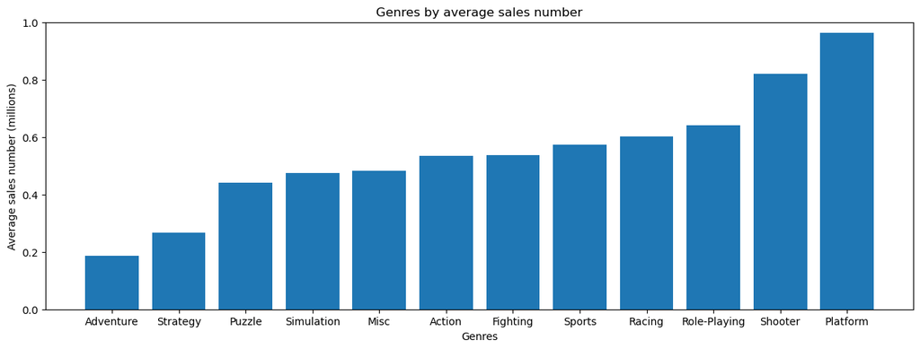

```python
# Visulization
plt.figure(figsize=(15,5))
plt.bar(range(0,12), list(clean_df.groupby('Genre')['Global_Sales'].mean().sort_values().values), tick_label=list(clean_df.groupby('Genre')['Global_Sales'].mean().sort_values().index))
plt.title('Genres by average sales number')
plt.xlabel('Genres')
plt.ylabel('Average sales number (millions)');
plt.ylim(0,1);
```